# Part II - PISA exploration

## by David Guillaume

## Investigation Overview

We will use the PISA dataset from 2012 to answer the following questions: 1) Effect of digitalization on school performance  
2) knowing more language helps you at school ? 3) Does your parent's background have an impact on your performance?

## Dataset Overview

The [PISA](https://www.oecd.org/pisa/) project is led by the OECD (Organization for Economic Co-operation and Development). PISA stands for Program for International Student Assessment and the goal is to retrieve data about the education level. The gathering of data (with a survey of 510 000 students (Sample)) is done every 3 years. The data frame we’ll deal with is from 2012.

# Digitalization interest

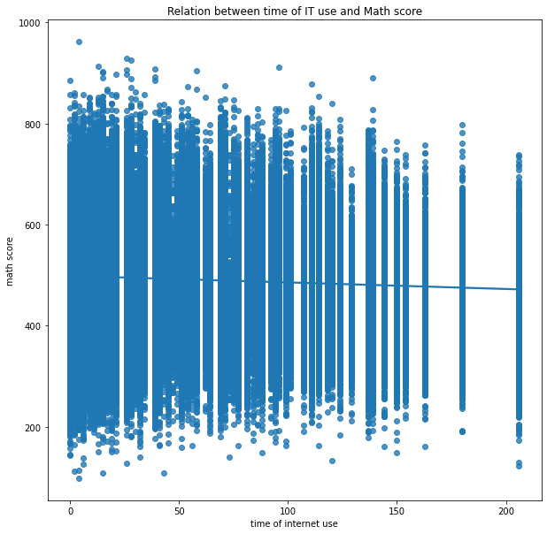

# Language interest

> Relationship between **being bilingual** and **read score**  
> Key insight: No significative relationship found between **being bilingual** and **read score**

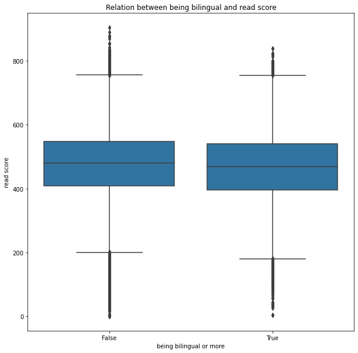

# Parent background interest

> Relationship between **parent education level** and **science score**  
> Key insight: **Positive** relationship found between **parent education level** and **science score**

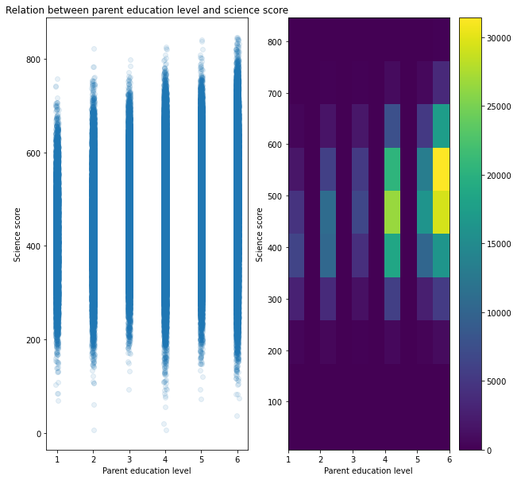